# Data Science Immersive: Data Visualization

### 3.1.2 Summary statistics:

Other common statistics that you’ll often apply summary statistics. Before we proceed, let’s clean up our data. I will use some base package functions to convert `cyl` and `am` to proper factor variables.

```r
mtcars$fcyl <- as.factor(mtcars$cyl)
mtcars$fam <- as.factor(mtcars$am)
```

We saw that positions are defined with the `position` argument within an geom, but we can also specify them using functions. As you would expect these functions take the form `position_*()`. The two advantages of defining positions in a function are that we can specify the arguments precisely, and we can reuse positions in many layers or in many plots.

```r
posn_d <- position_dodge(0.3)
posn_j <- position_jitter(0.3)
posn_jd <- position_jitterdodge(0.3, dodge.width = 0.3)
```

All right let’s begin to make a plot. Here’s the base layer with 3 variables:

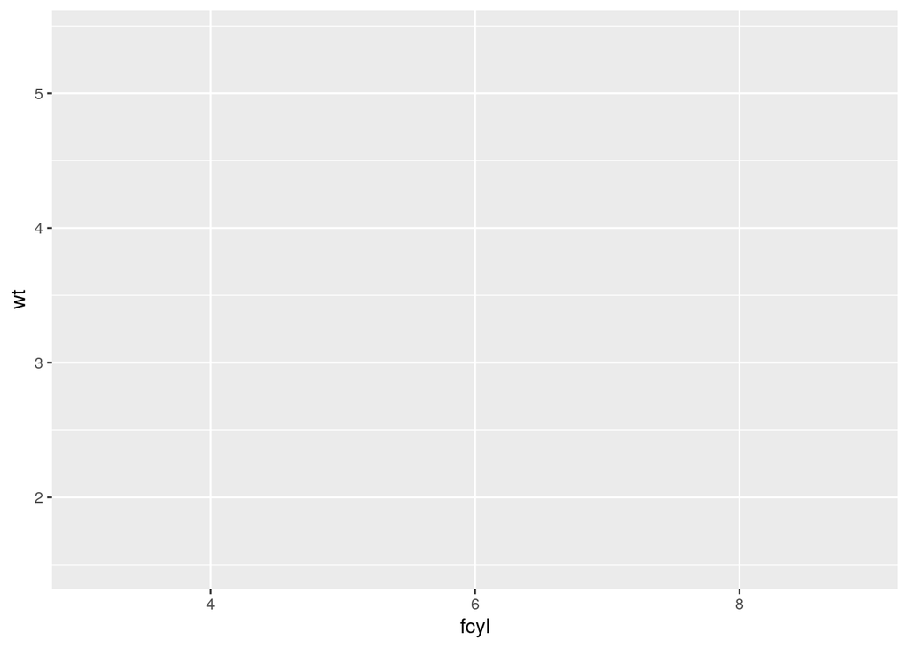

```r
q <- ggplot(mtcars, aes(fcyl, wt, col = fam))
q
```

First thing we want is to plot individual points.

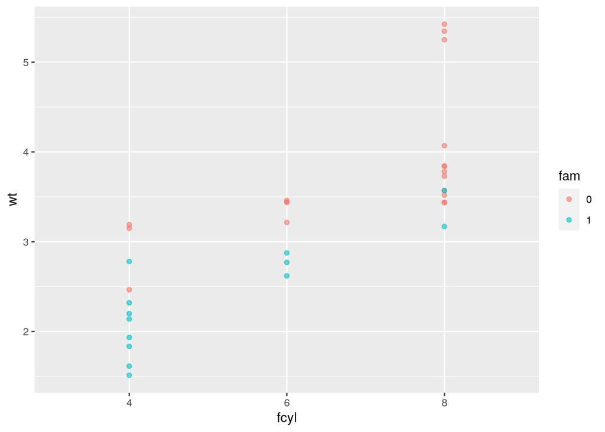

```r
q +
  geom_point(alpha =  0.6)
```

You can see the case for jittering here. We can use `geom_jitter()` and specify the width.

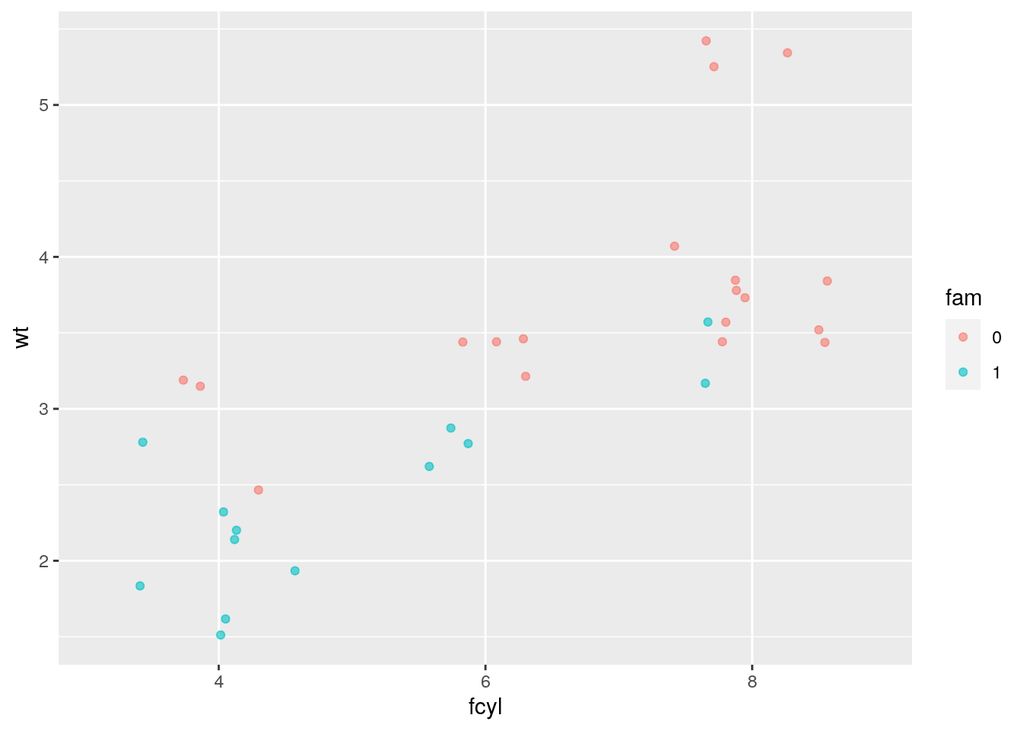

```r
q +
  geom_jitter(width = 0.3, alpha =  0.6)
```

But we can also use `geom_point()` and specify jittering using our position function.

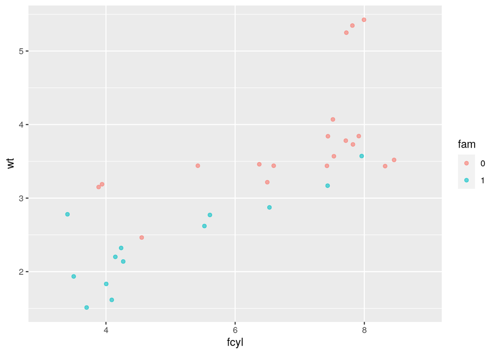

```r
q +
  geom_point(position = posn_j, alpha =  0.6)
```

Indeed, we may want to have not just jittering, but both jitter and dodge.

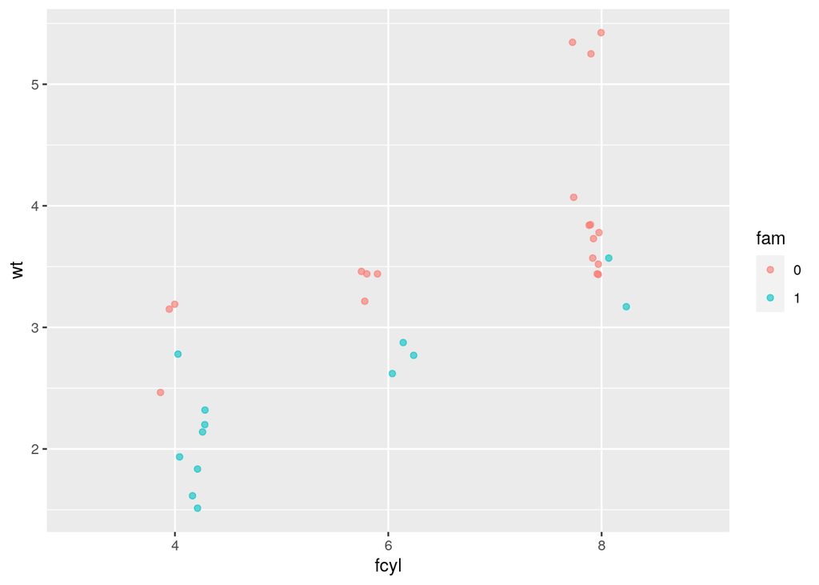

```r
q +
  geom_point(position = posn_jd, alpha =  0.6)
```

Let’s add some statistics: the mean and standard deviation. Before we plot the mean and standard deviation, let’s take a look at how we are going to get them. I’ll begin with some random numbers as an example:

```r
set.seed(136)
xx <- rnorm(100, 10, 6)
mean(xx)
```

```
## [1] 9.936956
```

```r
sd(xx)
```

```
## [1] 6.107339
```

The function were going to use to calculate the mean and standard deviation, `smean.sdl()`, comes from the `Hmisc` package. The `mult` argument says we only want one multiple of the standard deviation. We loaded this package at the beginning of the script.

```r
smean.sdl(xx, mult = 1)
```

```
##      Mean     Lower     Upper
##  9.936956  3.829617 16.044295
```

I loaded the package because I wanted to show you how it works, but if you want to do this in your own functions you don’t need to explicitly called `Hmisc`. That’s because the `ggplot2` function we’re going to use, `mean_sdl()`, will call the `Hmisc` function for us.

```r
mean_sdl(xx, mult = 1)
```

```
##          y     ymin    ymax
## 1 9.936956 3.829617 16.0443
```

Can you spot the difference in the output format? The ggplot2 function returns a dataframe. Each variable is named after an aesthetic we need to plot: the mean and the mean +/- 1 standard deviation, thus `ymin`, `y`, and `ymax`. `ymin` and `ymax` work just like X, Y, color, etc. that we saw before. To use this function inside our plot, use:

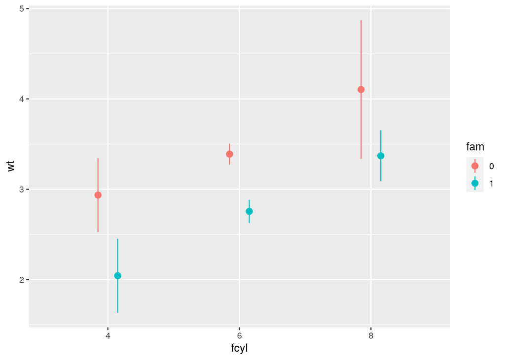

```r
q +
  stat_summary(fun.data = mean_sdl,
               fun.args = list(mult = 1),
               position = posn_d)
```

There are 3 things to note inside here.

First, we specified to function without brackets, `mean_sdl`, to the `fun.data` argument. This argument expects the output that we saw above including all three aesthetics. If we only want to specify one, we can use `fun.ymin`, `fun.y`, `fun.ymax` or any combination. You probably guessed that the `fun` part means *function*.

Second, notice that `mult = 1` is necessary, and in `stat_summary()`, We need to provide arguments to our stat function as a list to the `fun.args` argument.

Third, we again set the position using a previously defined object.

Let’s move onto inferential statistics: the mean and the 95% CI. The function to use here is `mean_cl_normal()`. It works exactly like what we saw earlier with `mean_sdl()`, except we don’t need to specify any arguments since it defaults to 95%. Although it has normal in the name, it is the t-corrected 95% CI. In this case we only need to dodge.

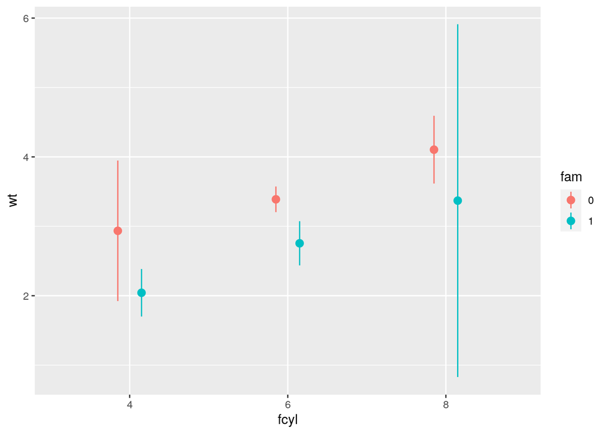

```r
q +
  stat_summary(fun.data = mean_cl_normal,
               position = posn_d)
```

We can of course combine individual points and a summary:

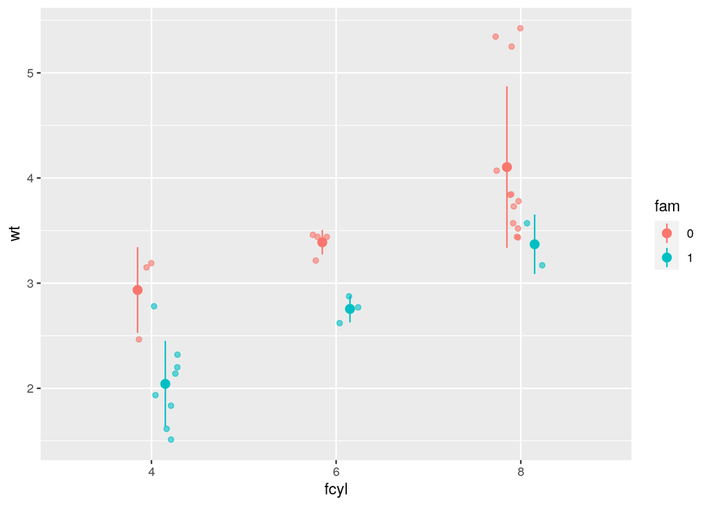

```r
q +
  geom_point(position = posn_jd, alpha =  0.6) +
  stat_summary(fun.data = mean_sdl,
               fun.args = list(mult = 1),
               position = posn_d)
```

## 3.2 Layer 5: Coordinates

In the video course, I presented the `coord_` layer in the context of the aspect ratio. Here I want to take a look at a very important practical aspect. Continue with the plot we just made above, where we had the mean and standard deviation:

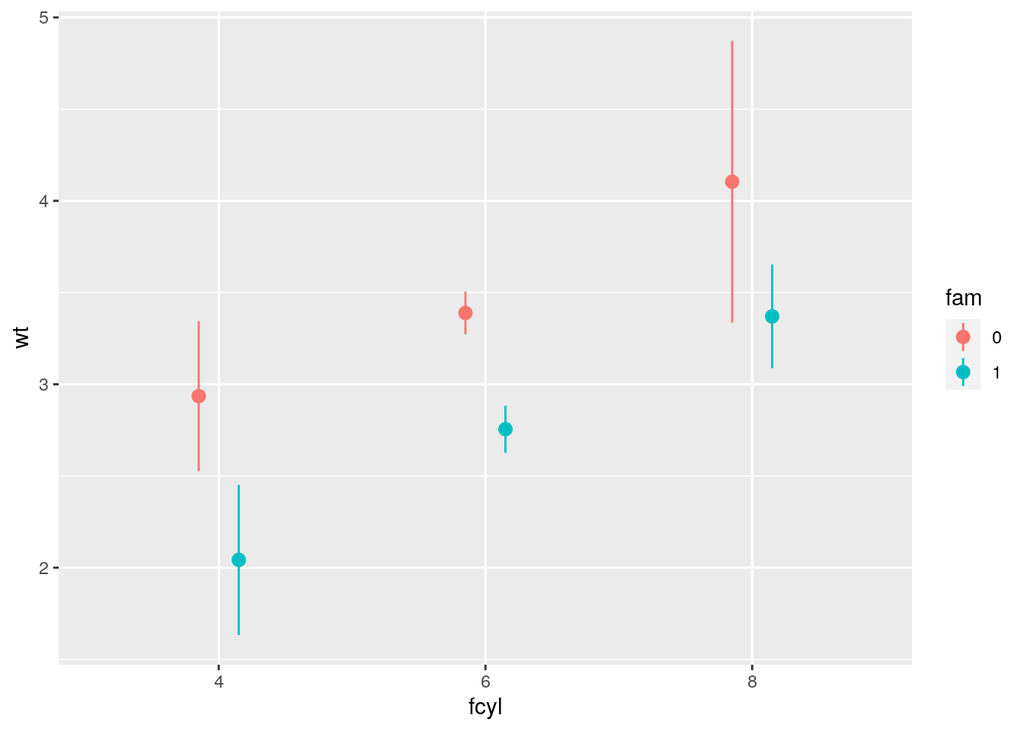

```r
q +
  stat_summary(fun.data = mean_sdl,
               fun.args = list(mult = 1),
               position = posn_d)
```

Imagine that I now want to set a limit on the Y axis, since the error bars don’t go above 5.

```r
q +
  stat_summary(fun.data = mean_sdl,
               fun.args = list(mult = 1),
               position = posn_d) +
  scale_y_continuous(limits = c(1,5),
                     expand = c(0,0))
```

```
## Warning: Removed 3 rows containing non-finite values (stat_summary).
```

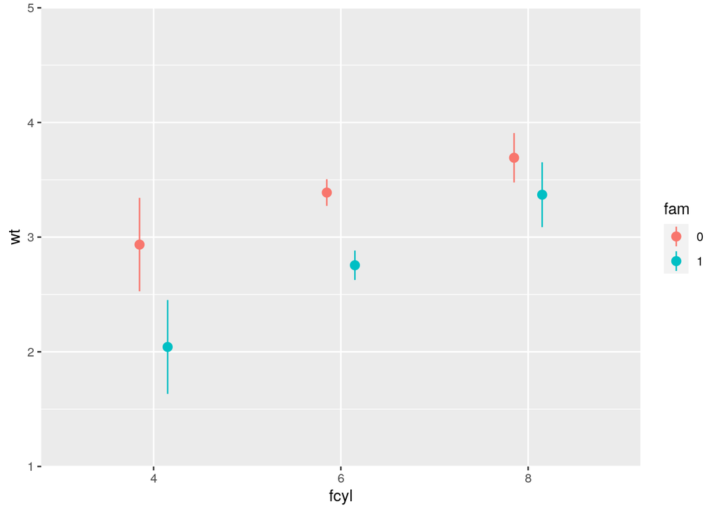

Compare the two plots above. Do you notice that the error bars are different, and that we got a warning message? This is a serious concern! Why did the error bars change? This is why I mentioned earlier that you should never just apply scale functions without first seeing all of your data.

The scale functions will *filter* data that is *outside* of the limits. That means that all of the automatically calculated statistics, like the mean and standard deviation, will be calculated *only* on that filtered dataset. This may be what you want, but it’s probably not.

What we really want to do is zoom in on the plot, but not filter the data. With this we can use a coordinate function. As you probably already expected these all have the form `coord_*()`.

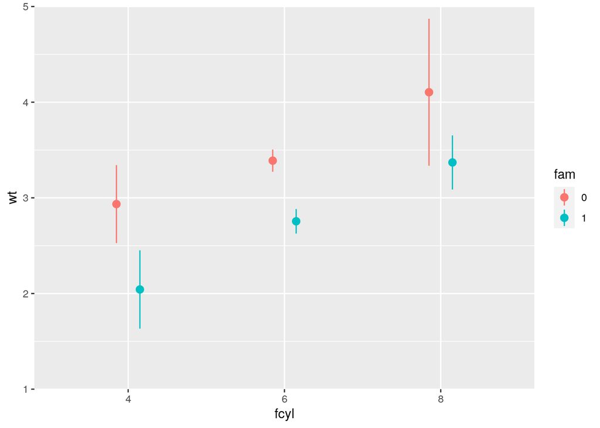

```r
q +
  stat_summary(fun.data = mean_sdl,
               fun.args = list(mult = 1),
               position = posn_d) +
  scale_y_continuous(expand = c(0,0)) +
  coord_cartesian(ylim = c(1,5))
```

## 3.3 Layer 6 Facets, Small Multiples

Small multiples are implemented with the facet later. Again, they following a nice naming convention. Each function follows the form `facet_*()`. There are a couple ways in which we can input variables. I tend to prefer formula notation: `y ~ x`, Which in this case becomes `rows ~ columns`.

When you have a small number of groups in a categorical variable, you can use `facet_grid()`. Let’s begin with an example:

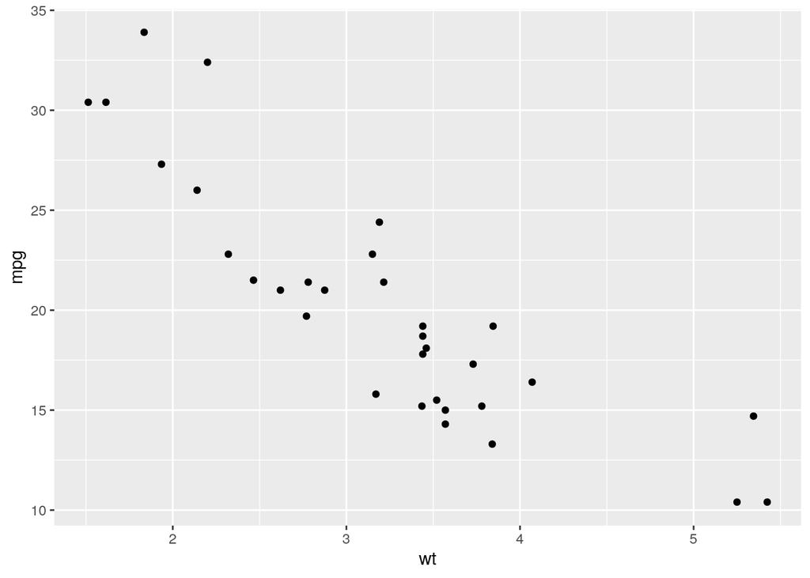

```r
m <- ggplot(mtcars, aes(wt, mpg)) +
  geom_point()

m
```

Split by rows:

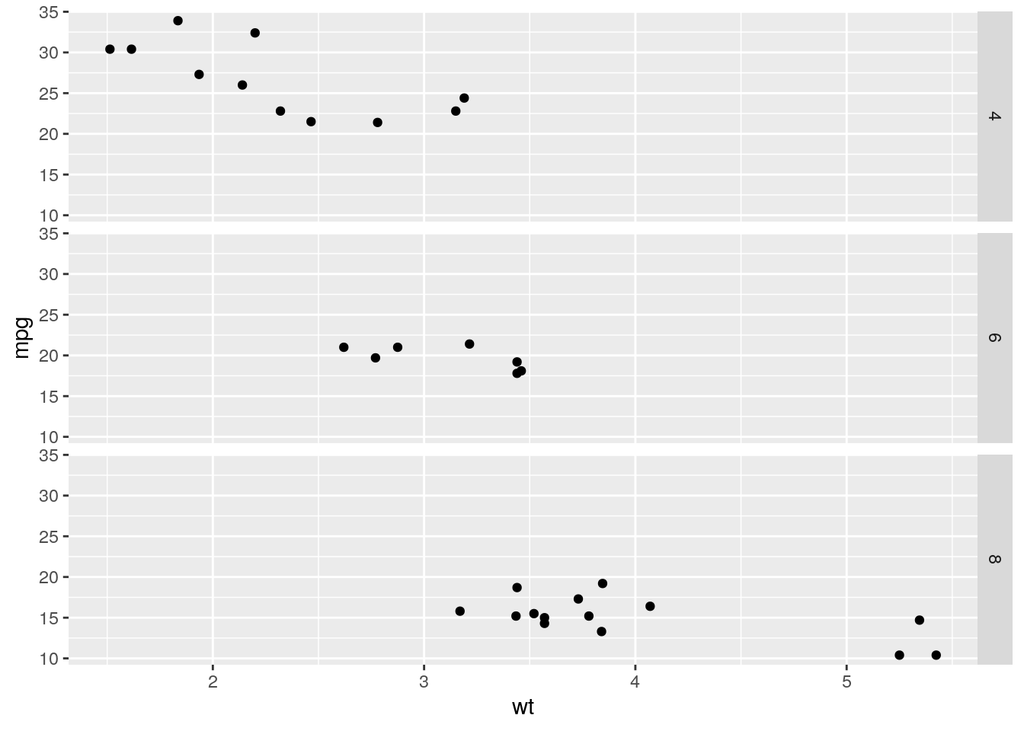

```r
m + facet_grid(cyl ~ .)
```

Split by columns:

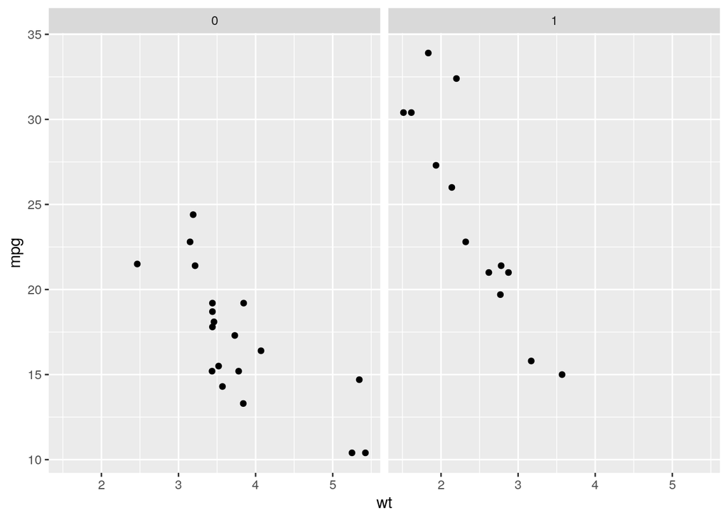

```r
m + facet_grid(. ~ am)
```

Split by both:

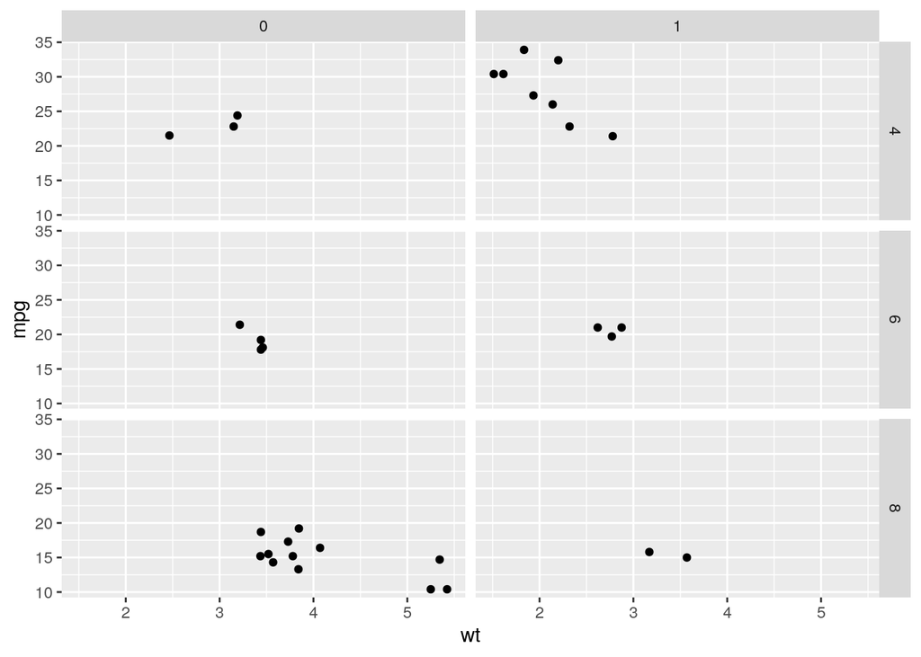

```r
m + facet_grid(cyl ~ am)
```

Noticed that cyl and am are numeric. `ggplot2` will convert these to factors. If we want to set the order, we should make them factors ourselves and properly set the order of the levels. See the Factors chapter in the *Data Analysis with R* course for more details.

For many groups, use `facet_wrap()`:

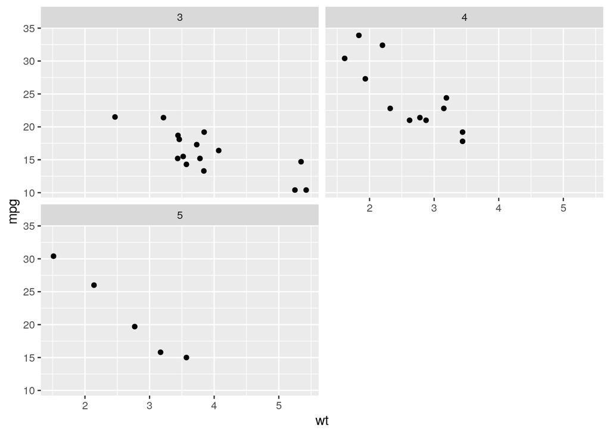

```r
m + facet_wrap(~ gear, ncol = 2)
```

## 3.4 Layer 7: Themes, Non-data Ink

The themes layer is where we modify all of the non-data ink on our plot. Just like all the other layers the functions here take the form `theme_*()`. For example, there are many built-in themes. Probably the the most useful is:

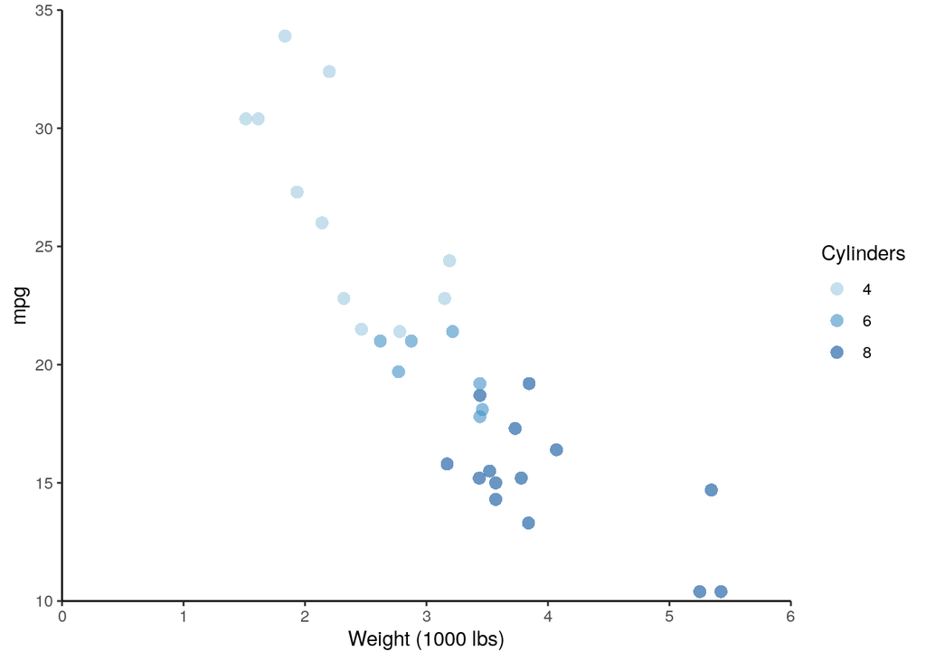

```r
p +
  theme_classic()
```

But `theme()` allows us to modify any non-data ink element on the plot. There are three types of non-data ink: text, lines and rectangles. Each element gets an intuitive name, using a `.` notation. The name tells us which level of the hierarchy of specific element falls into. All of these names are arguments in `theme()`. For example, for text elements:

```
theme(
text,
  axis.title,
    axis.title.x,
      axis.title.x.top,
      axis.title.x.bottom,
    axis.title.y,
      axis.title.y.left,
      axis.title.y.right,
  title,
    legend.title,
    plot.title,
    plot.subtitle,
    plot.caption,
    plot.tag,
  axis.text,
    axis.text.x,
      axis.text.x.top,
      axis.text.x.bottom,
    axis.text.y,
      axis.text.y.left,
      axis.text.y.right,
  legend.text,
  strip.text,
    strip.text.x,
    strip.text.y)
```

For line elements:

```
theme(
line,
  axis.ticks,
    axis.ticks.x,
      axis.ticks.x.top,
      axis.ticks.x.bottom,
    axis.ticks.y,
      axis.ticks.y.left,
      axis.ticks.y.right,
    axis.line,
      axis.line.x,
        axis.line.x.top,
        axis.line.x.bottom,
      axis.line.y,
        axis.line.y.left,
        axis.line.y.right,
  panel.grid,
    panel.grid.major,
      panel.grid.major.x,
      panel.grid.major.y,
    panel.grid.minor,
      panel.grid.minor.x,
      panel.grid.minor.y)
```

And for rectangle elements:

```
theme(
rect,
  legend.background,
  legend.key,
  legend.box.background,
  panel.background,
  panel.border,
  plot.background,
  strip.background,
    strip.background.x,
    strip.background.y)
```

To modify an element, just call its argument in `theme()` and apply the modification using either `element_text()`, `element_ _line()`, or `element_rect()`, depending on the element you are modifying. e.g.

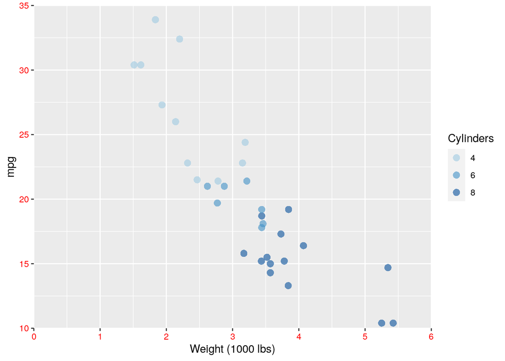

```r
p +
  theme(axis.text = element_text(colour = "red"))
```

There is one other element function that we haven’t discussed yet: `element_blank()`. We can use this in a plot to remove any item. That is, it won’t be drawn at all. In this example I set all rectangles to blank:

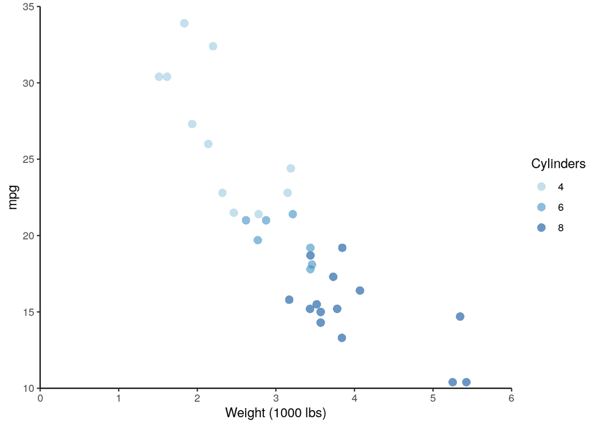

```r
p +
  theme_classic() +
  theme(rect = element_blank())
```

Actually, in addition to non-data ink we also modify the position of specific elements on the plot, like margins and spacing, in the themes layer. The most common modification you may make is to change the position of the legend using the `legend.position` argument. This takes a character argument, e.g. `"none"` to remove the legend, or `"top"`, `"right"`, `"bottom"`, `"left"` to center it on that side of the plot.

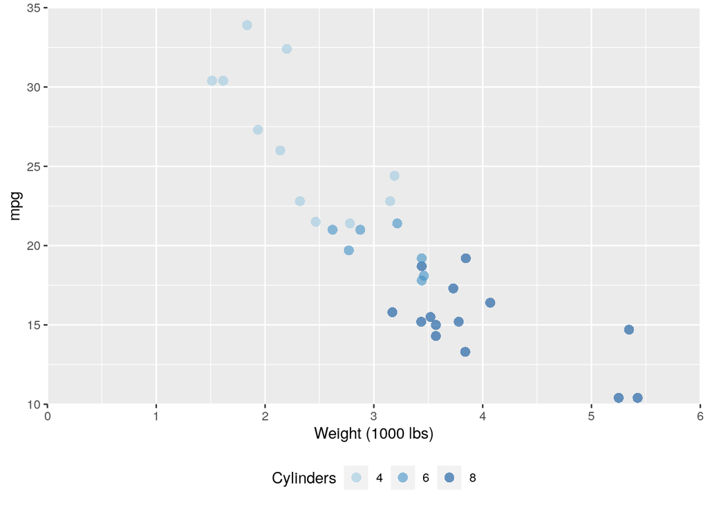

```r
p +
  theme(legend.position = "bottom")
```

You can position the legend inside the plot by specifying a two-element long numeric vector. Specifies the X and Y position of the legend in `npc` (Normalised Parent Coordinates) units. These values range from 0 to 1, where 0 is the min and 1 is the max value of the axis.

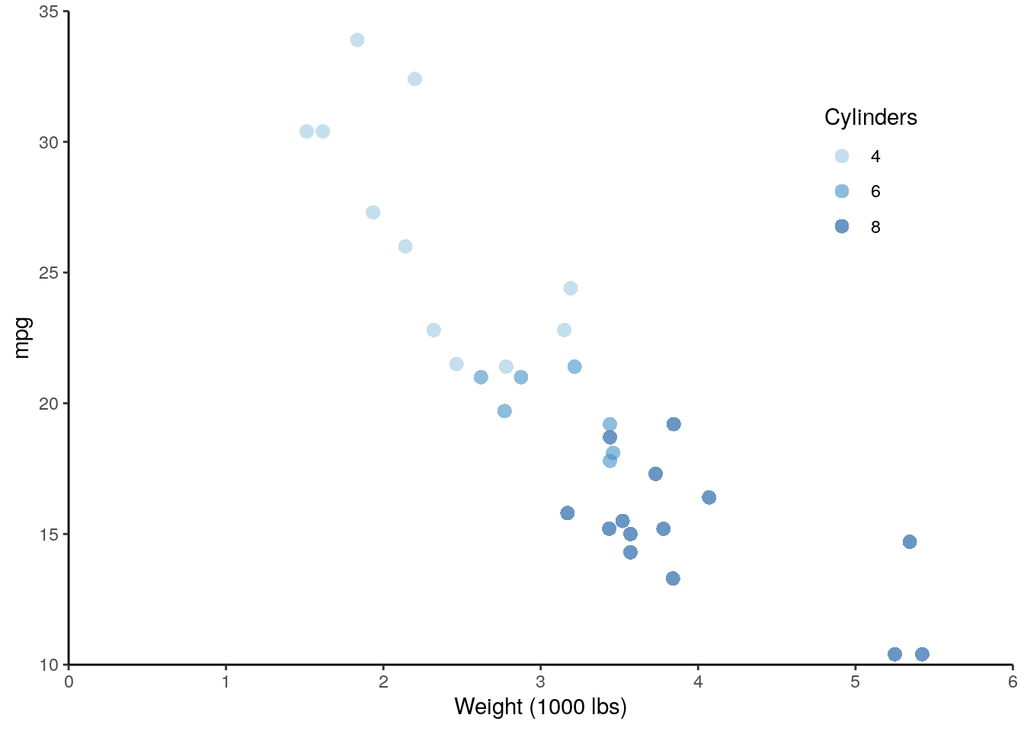

```r
p +
  theme_classic() +
  theme(legend.position = c(0.85, 0.75))
```

Of course we can combine this altogether:

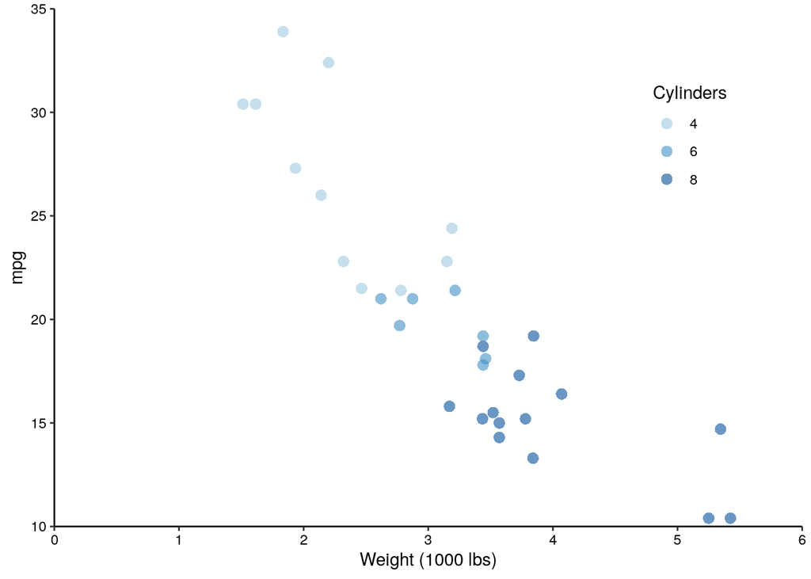

```r
p +
  theme_classic() +
  theme(rect = element_blank(),
        axis.text = element_text(colour = "black"),
        legend.position = c(0.85, 0.75))
```

# 4 Saving plots

Broadly speaking, there are two types of images: raster & vector.

Raster images have pixels & resolution. Think of the images your camera takes. Typical formats include: - jpg - png - tif - gif - bmp

Vector images don’t actually contain an image, they just have the instructions to make images. Typical formats include: - pdf - ai - svg - ps - eps

To save the last active image just run `ggsave()` after you print it to the screen.

```r
ggsave("myPlot.png", width = 6, height = 6, units = "in")
ggsave("myPlot.pdf", width = 6, height = 6, units = "in")
```

The extension on the file name will tell `ggsave()` what format to use to save the image. If we don’t specify a path, it will be saved to the working directory. That’s why it’s always good to work inside of a project in RStudio.

If you want to explicitly say which plot to save just specify it as the second argument.

```r
ggsave("myPlot_p.png", p, width = 6, height = 6, units = "in")
ggsave("myPlot_p.pdf", p, width = 6, height = 6, units = "in")
```